fossil

# Residue pair distances, dug back up.

A 2014 method turns a protein into counts of residue pairs at each distance and hands them to an SVM. Its software is gone. We ported the SVM from its C source and ran it again on the same benchmark. SVM-DR came back: its Table 1 ROC, nine of ten points of Fig. 3, and its discriminant weights in Figs 4B, 5C and 5D. SVM-DT needs profiles from a database that no longer exists. Rebuilt the way the lab's 2008 paper made them, they bring back its family-level results, while its average ROC lands about 0.01 above the paper's.

See Table 1

## Fig. 3

Average ROC of SVM-DR and SVM-DT against the distance threshold dMAX.

Partly agreesSVM-DR mean ROC per dMAX; SVM-DT re-measured

Published

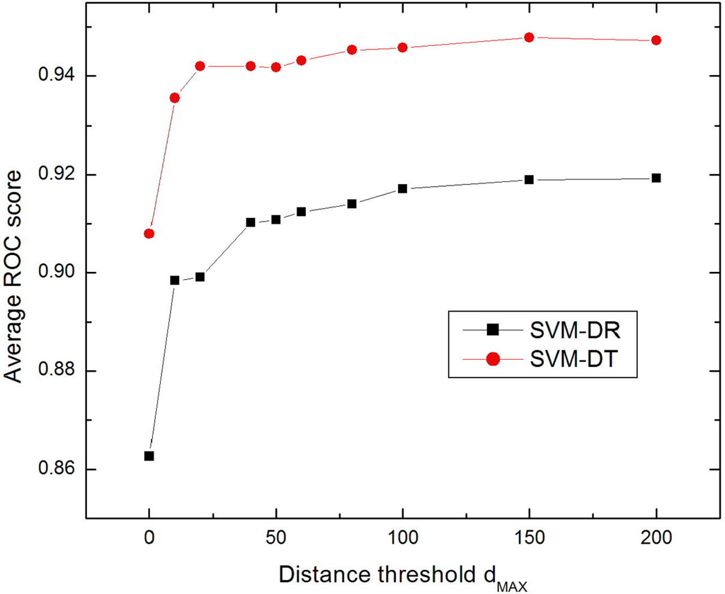

Our run

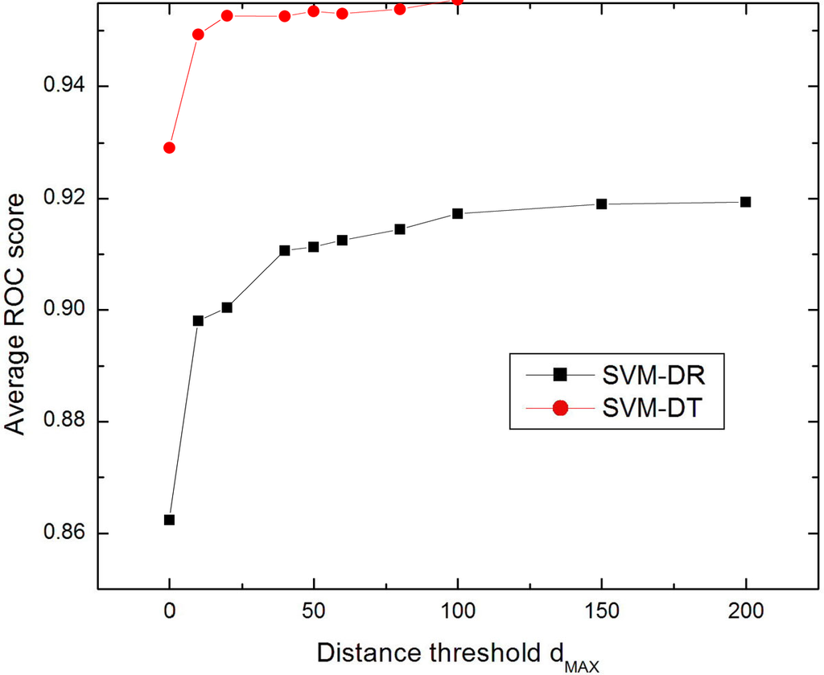

**SVM-DR, ink within 2 px**

84.4% (best control 75.9%)

**SVM-DR, points within 0.0005**

9 of 10

**SVM-DT, ink within 2 px**

0.0% (best control 0.0%)

**SVM-DT, points within 0.0005**

0 of 10

Mean ROC over the 54 families at each dMAX, ours drawn as the paper's markers on its own axes; frame, ticks and legend are the published pixels. SVM-DR at dMAX 150: 0.9189 (paper 0.919). SVM-DT at dMAX 150: 0.9570 (paper 0.948). SVM-DT is rerun on regenerated profiles. The paper's 2014 profile database no longer exists, so we built the profiles the way the paper's reference [28] describes (10 PSI-BLAST iterations, BLOSUM62 pseudocounts) against the lab's 2016 nrdb90. Everything after the profiles is the code that reproduces SVM-DR's panels almost exactly. These profiles bring back family 2.5.1.3 (ROC 0.993, as published) and the order of its top pairs, and move Figs 4A and 5A-B closer than the lab's later 3-iteration settings did. The 54-family average lands about 0.01 above the paper at every dMAX (0.957 against 0.948), which we put down to the database, untested. These items are marked Re-measured.

## Fig. 4

L2 norm of the discriminant weights of each pair, family 2.5.1.3: (A) Top-1-gram pairs, SVM-DT; (B) residue pairs, SVM-DR.

AgreesPanel B, cell greys within 24; panel A re-measured

Published

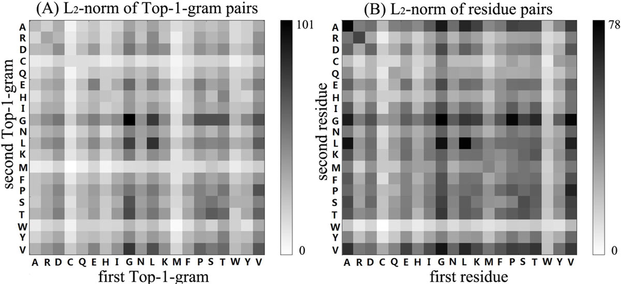

Our run

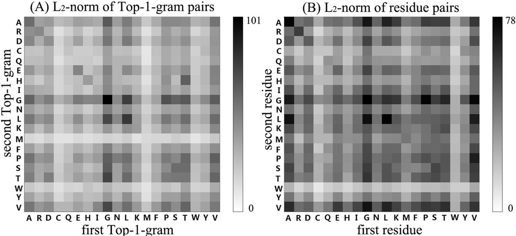

**(A) Spearman with published**

0.875

**(A) maximum, ours / paper**

103 / 101

**(A) rank of (G,G), (L,L)**

1, 2 (paper 1, 2)

**(B) Spearman with published**

1.000

**(B) maximum, ours / paper**

78 / 78

**(B) rank of (G,G), (L,L)**

1, 2 (paper 1, 2)

Cells filled with the published colour bar's grey for our L2 norm, on the paper's scale. The published cells are read back through the same bar. SVM-DT is rerun on regenerated profiles. The paper's 2014 profile database no longer exists, so we built the profiles the way the paper's reference [28] describes (10 PSI-BLAST iterations, BLOSUM62 pseudocounts) against the lab's 2016 nrdb90. Everything after the profiles is the code that reproduces SVM-DR's panels almost exactly. These profiles bring back family 2.5.1.3 (ROC 0.993, as published) and the order of its top pairs, and move Figs 4A and 5A-B closer than the lab's later 3-iteration settings did. The 54-family average lands about 0.01 above the paper at every dMAX (0.957 against 0.948), which we put down to the database, untested. These items are marked Re-measured.

## Fig. 5

Discriminant weights of (G,G) and (L,L) against distance, family 2.5.1.3.

AgreesPanels C and D, bars within 2 px; A and B re-measured

Published

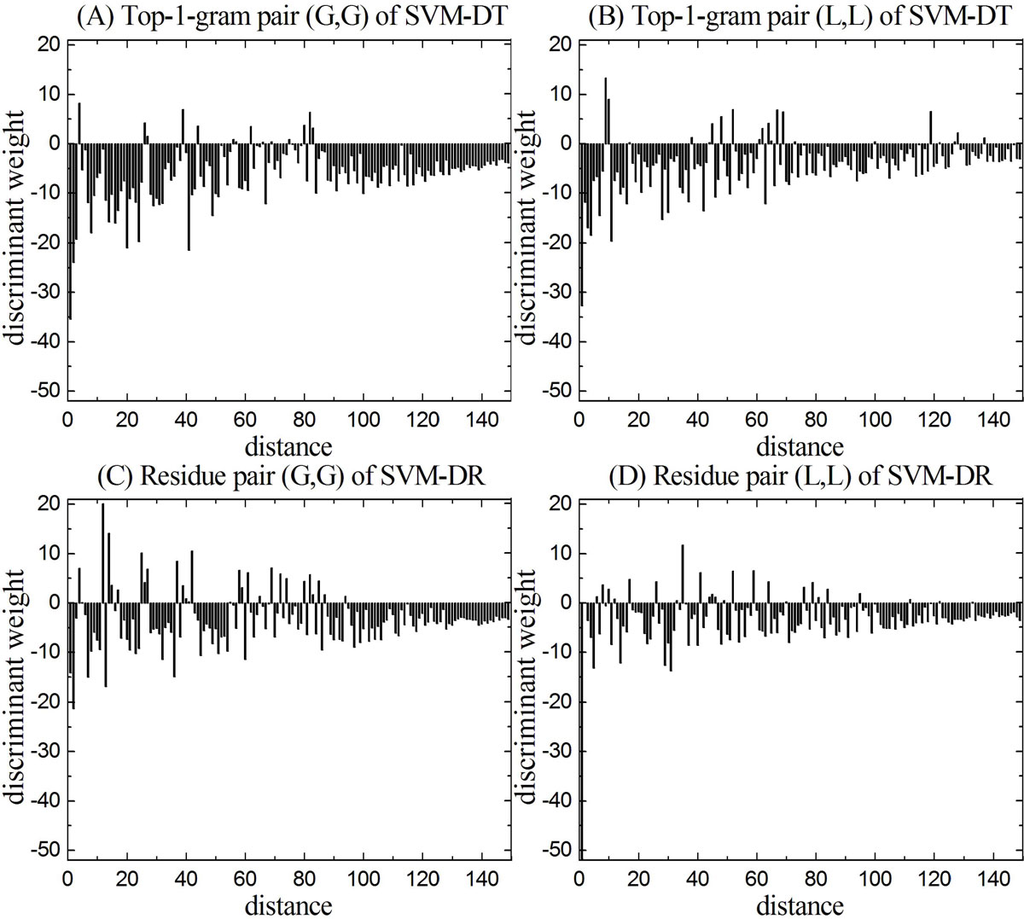

Our run

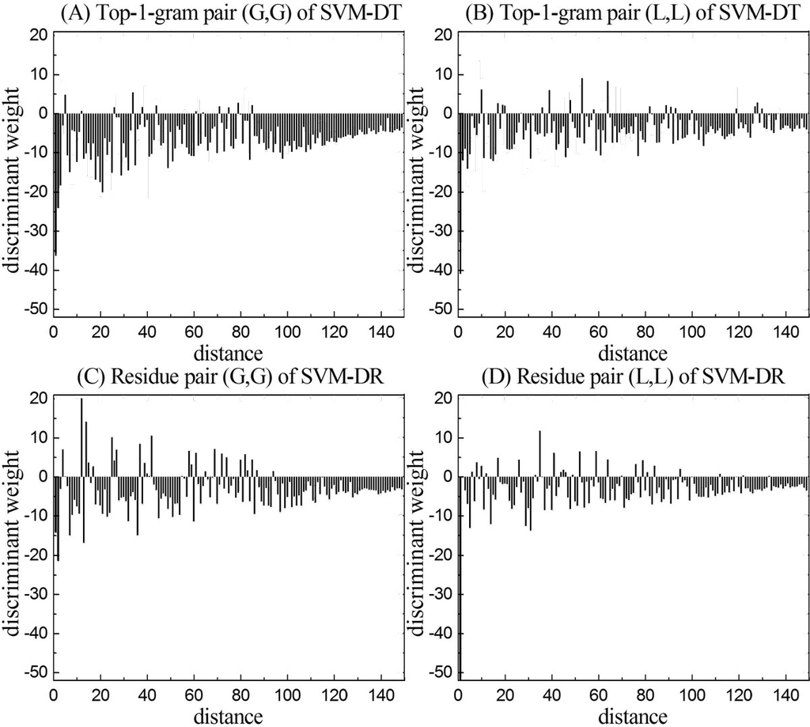

**(A) G,G SVM-DT**

r 0.58, scale 0.83

**(B) L,L SVM-DT**

r 0.50, scale 0.83

**(C) G,G SVM-DR**

r 1.00, scale 1.02

**(D) L,L SVM-DR**

r 1.00, scale 1.03

Our weights drawn as bars at x = d + 1, where the published bars sit (the correlation with the published bars is highest at that offset in every panel). Scale is the least-squares factor of the published bars on ours; it is reported, not applied. SVM-DT is rerun on regenerated profiles. The paper's 2014 profile database no longer exists, so we built the profiles the way the paper's reference [28] describes (10 PSI-BLAST iterations, BLOSUM62 pseudocounts) against the lab's 2016 nrdb90. Everything after the profiles is the code that reproduces SVM-DR's panels almost exactly. These profiles bring back family 2.5.1.3 (ROC 0.993, as published) and the order of its top pairs, and move Figs 4A and 5A-B closer than the lab's later 3-iteration settings did. The 54-family average lands about 0.01 above the paper at every dMAX (0.957 against 0.948), which we put down to the database, untested. These items are marked Re-measured.

## Table 1

Average ROC and ROC50 over the 54 families. Our run for SVM-DR and SVM-DT at dMAX = 150; the other rows are quoted by the paper from earlier work and were not rerun.

Partly agreesSVM-DR at the printed precision; SVM-DT re-measured

Table 1 (paper ROC, ROC50; ours ROC, ROC50)

| Method | Paper ROC | Paper ROC50 | Ours ROC | Ours ROC50 |
| --- | --- | --- | --- | --- |
| SVM-DR | 0.919 | 0.715 | **0.919** | **0.497** |
| Monomer-dist | 0.919 | 0.508 | quoted | quoted |
| SVM-LA | 0.925 | 0.649 | quoted | quoted |
| SVM-Pairwise | 0.901 | 0.399 | quoted | quoted |
| SVM-DT | 0.948 | 0.800 | **0.957** | **0.720** |
| SVM-Top-n-gram | 0.907 | 0.696 | quoted | quoted |
| SVM-Top-n-gram-LSA | 0.939 | 0.767 | quoted | quoted |
| SVM-PDT-Profile | 0.950 | 0.740 | quoted | quoted |
| PseAACIndex-Porfile | 0.922 | 0.712 | quoted | quoted |
| BioSVM-2L | 0.927 | 0.888 | quoted | quoted |
| HHSearch | 0.915 | 0.990 | quoted | quoted |

SVM-DT is rerun on regenerated profiles. The paper's 2014 profile database no longer exists, so we built the profiles the way the paper's reference [28] describes (10 PSI-BLAST iterations, BLOSUM62 pseudocounts) against the lab's 2016 nrdb90. Everything after the profiles is the code that reproduces SVM-DR's panels almost exactly. These profiles bring back family 2.5.1.3 (ROC 0.993, as published) and the order of its top pairs, and move Figs 4A and 5A-B closer than the lab's later 3-iteration settings did. The 54-family average lands about 0.01 above the paper at every dMAX (0.957 against 0.948), which we put down to the database, untested. These items are marked Re-measured.

Claims in the text (paper / ours)

[output not shown]

The main claim holds: pair distances add to a position-independent baseline, and SVM-DR comes back as published. The claims that do not match trace to the ROC50 definition and to the regenerated profiles.

## What stayed buried

- Fig. 1: A worked example of the feature vector (AGLP to KFFK, dMAX = 2); nothing to recompute.
- Fig. 2: Pseudocode of the Distance-based Top-1-gram vector; it is the method, implemented in features.py.
- Table 1, the nine other methods: Quoted by the paper from earlier work (Monomer-dist, SVM-LA, SVM-Pairwise, SVM-Top-n-gram and -LSA, SVM-PDT-Profile, PseAACIndex-Profile, BioSVM-2L, HHSearch); not results of this paper.
- The authors’ DistanceSVM package and server (bioinformatics.hitsz.edu.cn answers 503)
- The 2014 profile database and PSI-BLAST settings

## What we matched

The figures were drawn with tools we do not have, so we keep the published frame, ticks, labels and legends and draw only the data, at sizes measured from the figure. Fig. 3 points sit on an axis map fitted to the tick marks. Fig. 4 cells take the grey of the published colour bar. Fig. 5 bars sit at x = d + 1, where the published bars are.

**Our run**

The 54 SCOP 1.53 families of Liao and Noble, the feature vectors of the paper's Eq. 1 and 2, and Gist 2.3 ported from its C source with its default settings.

**One change to Gist**

Identical sequences can give a normalized kernel value one rounding step above 1, which Gist sets to 0. That breaks training. We set it to 1, and the published weights come back.

**Profiles**

Built as in the lab's 2008 Top-n-gram paper, which the paper cites: PSI-BLAST 2.17 with default settings and 10 iterations against the lab's 2016 nrdb90, then BLOSUM62 pseudocounts. The paper's own database is not known.

**Reading the views**

Overlay: ink is the paper only, light green is the reproduction only, dark green is both. Difference: darker means a larger grey difference.

## The session

The reproduction was done by an AI agent, Claude Code, in one session. Every prompt, reply and tool call of it is published.

**Wall clock**

3.5 days

first message to last, waits included

**Human prompts**

4

messages typed by a person

**Tool calls**

511

none in subagents

**Tokens**

204.9 M

every request, subagents included

Read the session [The raw files](https://github.com/jeonglab-bcm/fossil/tree/main/PMC4015815/session)